# **secr** simulations MID

Murray Efford

2025-03-20

# Mis-identification as source of bias in SECR

The simulations described here are part of a series documenting the effect of breaching assumptions of spatially explicit capture–recapture models.

## Problem description

Detected animals may be

1. mis-identified as an existing marked (known) individual, or
2. mistakenly identified as a new ‘ghost’ individual, or
3. indistinguishable from another with the same genotype at the loci sampled, or
4. mistakenly tagged as a new individual after loss of a previous tag.

We simulate these mechanisms separately (MID1, MID2, MID3, MID6).

## Settings

MID1-5 Square grid of 64 binary proximity detectors at spacing $c = 2\sigma$.  
MID6 Square grid of 64 multi-catch traps at spacing $c = 2\sigma$.

The same conditions were used for simulation and fitting.

| Parameter |  | Value(s) |
| --- | --- | --- |
| detectfn |  | ‘HHN’ |
| D |  | $12.5 \sigma^{-2}$ |
| lambda0 |  | 0.1 |
| sigma |  | c/2 |
| noccasions |  | 10 |
| buffer |  | $4\sigma$ |
| nx |  | 32 |

## Package version, date and platform

```r
source('../setup.R')
runsim  <- FALSE
figures <- TRUE
cache   <- TRUE
nrepl   <- 200
metadata(runsim) # if FALSE picks up saved metadata.RDS
```

```
## R version 4.3.2 (2023-10-31)
## Platform   x86_64-pc-linux-gnu (64-bit)
## Running    CentOS Linux 7 (Core)
## secr       4.6.7 2024-05-18
## secrdesign 2.9.2 2024-05-18
## Threads    40
## Run        Wed Jun 12 09:57:06 2024
```

## Simulation code

This alternative capthist simulation function generates a capthist the usual way with `sim.capthist` and then scrambles the identities according to one of the four mechanisms.

```r
simMID.capthist <- function(traps, popn, detectfn, detectpar = list(),
                            noccasions = 10, pMID = 0, pGhost = 0, PI = 0,
                            pTagloss = 0, ...)
{
    ch0 <- sim.capthist(traps, popn, detectfn, detectpar, noccasions)
    n <- nrow(ch0)
    capt <- as.data.frame(ch0)
    capt$ID <- as.integer(capt$ID)
    newcapt <- capt
    if (pMID > 0) {
        # on any occasion, ID reassigned to any known animal with probability pMID
        whichmisID <- runif(nrow(capt)) < pMID
        newID <- sample.int(n, size = sum(whichmisID), replace = TRUE)
        newcapt$ID[whichmisID] <- newID
    }
    else if (pGhost>0) {
        # proportion pGhost of all detections receive unrepeatable ID
        novel <- runif(nrow(capt)) < pGhost
        newcapt$ID[novel] <- paste('N',capt$ID[novel], capt$Occasion[novel], capt$TrapID[novel], sep='.')
    }
    else if (PI>0) {
        pairwise <- 1 - matrix(runif(n*n) < PI, nrow = n)
        # find any pairs, triplets etc. with zero distance and assign common ID
        d <- as.dist(pairwise)   # uses only lower triangle of pairwise
        groupID <- cutree(hclust(d, 'single'), h = 0.1)  # groups individuals linked by dist==0
        newcapt$ID <- groupID[capt$ID]
    }
    else if (pTagloss>0) {
        # detections receive new ID with probability dependent on interval from last
        elapsed <- c(NA, diff(capt$Occasion))           # assume sorted by ID, occasion
        elapsed[match(unique(capt$ID), capt$ID)] <- NA  # not first
        novel <- runif(nrow(capt)) < (1 - (1-pTagloss)^elapsed)
        novel[is.na(novel)] <- FALSE
        novelist <- split(novel, capt$ID)  # assumes ID ordered factor levels
        subID <- unlist(lapply(novelist, cumsum))
        newcapt$ID <- paste('N',capt$ID, subID, sep='.')
    }
    # re-read
    ch <- make.capthist(newcapt, traps, noccasions = noccasions)
    if (PI>0) {
        identicalpairs <- cbind(as.numeric(row(pairwise)), as.numeric(col(pairwise)))[!as.logical(pairwise),]
        attr(ch, 'identicalpairs') <- identicalpairs
        attr(ch, 'groupID') <- groupID
    }
    ch
}
```

```r
grid <- make.grid(nx = 8, ny = 8, spacing = 40, detector = "proximity")
fitarg <- list(detectfn = 'HHN', model = lambda0 ~ 1, start = NULL)
```

### Run MID simulations

```r
detarg1 <- expand.arg(pMID = c(0.00, 0.01, 0.02, 0.05, 0.1, 0.15, 0.2))
scen1 <- make.scenarios(D = 12.5, noccasions = 10, detectfn = 14,
    lambda0 = 0.1, sigma = 20, detindex = 1:length(detarg1), fitindex = 1)
```

```r
scenarioSummary(scen1, grid)
```

```
##   scenario trapsindex noccasions nrepeats    D lambda0 sigma detectfn     En     Er     Em    En2
## 1        1          1         10        1 12.5     0.1    20       14 110.03 86.116 55.021 40.795
## 2        2          1         10        1 12.5     0.1    20       14 110.03 86.116 55.021 40.795
## 3        3          1         10        1 12.5     0.1    20       14 110.03 86.116 55.021 40.795
## 4        4          1         10        1 12.5     0.1    20       14 110.03 86.116 55.021 40.795
## 5        5          1         10        1 12.5     0.1    20       14 110.03 86.116 55.021 40.795
## 6        6          1         10        1 12.5     0.1    20       14 110.03 86.116 55.021 40.795
## 7        7          1         10        1 12.5     0.1    20       14 110.03 86.116 55.021 40.795
##      esa CF rotRSE rotRSEB arrayN arrayspace arrayspan saturation detperHR.median       k
## 1 8.8021  1 0.1078  0.0858     64          2    19.799    0.26959               4 0.70711
## 2 8.8021  1 0.1078  0.0858     64          2    19.799    0.26959               4 0.70711
## 3 8.8021  1 0.1078  0.0858     64          2    19.799    0.26959               4 0.70711
## 4 8.8021  1 0.1078  0.0858     64          2    19.799    0.26959               4 0.70711
## 5 8.8021  1 0.1078  0.0858     64          2    19.799    0.26959               4 0.70711
## 6 8.8021  1 0.1078  0.0858     64          2    19.799    0.26959               4 0.70711
## 7 8.8021  1 0.1078  0.0858     64          2    19.799    0.26959               4 0.70711
```

```r
MIDsims1 <- run.scenarios(
    nrepl     = nrepl,
    scenarios = scen1,
    trapset   = grid,
    det.args  = detarg1,
    fit       = TRUE,
    fit.args  = fitarg,
    seed      = 1234,
    CH.function = "simMID.capthist")
saveRDS(MIDsims1, file = 'MIDsims1.RDS')
```

```r
detarg2 <- expand.arg(pGhost = c(0.00, 0.01, 0.02, 0.05, 0.1, 0.15, 0.2))
scen2 <- make.scenarios(D = 12.5, noccasions = 10, detectfn = 14,
    lambda0 = 0.1, sigma = 20, detindex = 1:length(detarg2), fitindex = 1)
```

```r
scenarioSummary(scen2, grid)
```

```
##   scenario trapsindex noccasions nrepeats    D lambda0 sigma detectfn     En     Er     Em    En2
## 1        1          1         10        1 12.5     0.1    20       14 110.03 86.116 55.021 40.795
## 2        2          1         10        1 12.5     0.1    20       14 110.03 86.116 55.021 40.795
## 3        3          1         10        1 12.5     0.1    20       14 110.03 86.116 55.021 40.795
## 4        4          1         10        1 12.5     0.1    20       14 110.03 86.116 55.021 40.795
## 5        5          1         10        1 12.5     0.1    20       14 110.03 86.116 55.021 40.795
## 6        6          1         10        1 12.5     0.1    20       14 110.03 86.116 55.021 40.795
## 7        7          1         10        1 12.5     0.1    20       14 110.03 86.116 55.021 40.795
##      esa CF rotRSE rotRSEB arrayN arrayspace arrayspan saturation detperHR.median       k
## 1 8.8021  1 0.1078  0.0858     64          2    19.799    0.26959               4 0.70711
## 2 8.8021  1 0.1078  0.0858     64          2    19.799    0.26959               4 0.70711
## 3 8.8021  1 0.1078  0.0858     64          2    19.799    0.26959               4 0.70711
## 4 8.8021  1 0.1078  0.0858     64          2    19.799    0.26959               4 0.70711
## 5 8.8021  1 0.1078  0.0858     64          2    19.799    0.26959               4 0.70711
## 6 8.8021  1 0.1078  0.0858     64          2    19.799    0.26959               4 0.70711
## 7 8.8021  1 0.1078  0.0858     64          2    19.799    0.26959               4 0.70711
```

```r
MIDsims2 <- run.scenarios(
    nrepl       = nrepl,
    scenarios   = scen2,
    trapset     = grid,
    det.args    = detarg2,
    fit         = TRUE,
    fit.args    = fitarg,
    seed        = 1234,
    CH.function = "simMID.capthist")
saveRDS(MIDsims2, file = 'MIDsims2.RDS')
```

```r
detarg3 <- expand.arg(PI = c(0.00, 10^(seq(-5,-2,0.5))))
scen3 <- make.scenarios(D = 12.5, noccasions = 10, detectfn = 14,
    lambda0 = 0.1, sigma = 20, detindex = 1:length(detarg3))
```

```r
scenarioSummary(scen3, grid)
```

```
##   scenario trapsindex noccasions nrepeats    D lambda0 sigma detectfn     En     Er     Em    En2
## 1        1          1         10        1 12.5     0.1    20       14 110.03 86.116 55.021 40.795
## 2        2          1         10        1 12.5     0.1    20       14 110.03 86.116 55.021 40.795
## 3        3          1         10        1 12.5     0.1    20       14 110.03 86.116 55.021 40.795
## 4        4          1         10        1 12.5     0.1    20       14 110.03 86.116 55.021 40.795
## 5        5          1         10        1 12.5     0.1    20       14 110.03 86.116 55.021 40.795
## 6        6          1         10        1 12.5     0.1    20       14 110.03 86.116 55.021 40.795
## 7        7          1         10        1 12.5     0.1    20       14 110.03 86.116 55.021 40.795
## 8        8          1         10        1 12.5     0.1    20       14 110.03 86.116 55.021 40.795
##      esa CF rotRSE rotRSEB arrayN arrayspace arrayspan saturation detperHR.median       k
## 1 8.8021  1 0.1078  0.0858     64          2    19.799    0.26959               4 0.70711
## 2 8.8021  1 0.1078  0.0858     64          2    19.799    0.26959               4 0.70711
## 3 8.8021  1 0.1078  0.0858     64          2    19.799    0.26959               4 0.70711
## 4 8.8021  1 0.1078  0.0858     64          2    19.799    0.26959               4 0.70711
## 5 8.8021  1 0.1078  0.0858     64          2    19.799    0.26959               4 0.70711
## 6 8.8021  1 0.1078  0.0858     64          2    19.799    0.26959               4 0.70711
## 7 8.8021  1 0.1078  0.0858     64          2    19.799    0.26959               4 0.70711
## 8 8.8021  1 0.1078  0.0858     64          2    19.799    0.26959               4 0.70711
```

```r
MIDsims3 <- run.scenarios(
    nrepl       = nrepl,
    scenarios   = scen3,
    trapset     = grid,
    det.args    = detarg3,
    fit         = TRUE,
    fit.args    = fitarg,
    seed        = 1234,
    CH.function = "simMID.capthist")
saveRDS(MIDsims3, file = 'MIDsims3.RDS')
```

```r
scen4 <- make.scenarios(D = 12.5 * c(0.25,0.5,1,2,4), noccasions = 10, detectfn = 14,
    lambda0 = 0.1, sigma = 20, detindex = 1:length(detarg3))
scen4 <- scen4[order(scen4$D, scen4$detindex),]
scen4$scenario <- 1:nrow(scen4)
```

```r
scenarioSummary(scen4, grid)
```

```
##    scenario trapsindex noccasions nrepeats      D lambda0 sigma detectfn      En      Er      Em
## 1         1          1         10        1  3.125     0.1    20       14  27.506  21.529  13.755
## 2         2          1         10        1  3.125     0.1    20       14  27.506  21.529  13.755
## 3         3          1         10        1  3.125     0.1    20       14  27.506  21.529  13.755
## 4         4          1         10        1  3.125     0.1    20       14  27.506  21.529  13.755
## 5         5          1         10        1  3.125     0.1    20       14  27.506  21.529  13.755
## 6         6          1         10        1  3.125     0.1    20       14  27.506  21.529  13.755
## 7         7          1         10        1  3.125     0.1    20       14  27.506  21.529  13.755
## 8         8          1         10        1  3.125     0.1    20       14  27.506  21.529  13.755
## 9         9          1         10        1  6.250     0.1    20       14  55.013  43.058  27.510
## 10       10          1         10        1  6.250     0.1    20       14  55.013  43.058  27.510
## 11       11          1         10        1  6.250     0.1    20       14  55.013  43.058  27.510
## 12       12          1         10        1  6.250     0.1    20       14  55.013  43.058  27.510
## 13       13          1         10        1  6.250     0.1    20       14  55.013  43.058  27.510
## 14       14          1         10        1  6.250     0.1    20       14  55.013  43.058  27.510
```

[output cut: 67 more lines]

```r
MIDsims4 <- run.scenarios(
    nrepl       = nrepl,
    scenarios   = scen4,
    trapset     = grid,
    det.args    = detarg3,
    fit         = TRUE,
    fit.args    = fitarg,
    seed        = 1234,
    CH.function = "simMID.capthist")
saveRDS(MIDsims4, file = 'MIDsims4.RDS')
```

```r
scen5 <- make.scenarios(D = 12.5, noccasions = 10, detectfn = 14,
    lambda0 = c(0.05,0.1,0.2), sigma = 20, detindex = 1:length(detarg3))
scen5 <- scen5[order(scen5$lambda0, scen5$detindex),]
scen5$scenario <- 1:nrow(scen5)
```

```r
scenarioSummary(scen5, grid)
```

```
##    scenario trapsindex noccasions nrepeats    D lambda0 sigma detectfn      En      Er      Em
## 1         1          1         10        1 12.5    0.05    20       14  72.661  26.625  17.062
## 2         2          1         10        1 12.5    0.05    20       14  72.661  26.625  17.062
## 3         3          1         10        1 12.5    0.05    20       14  72.661  26.625  17.062
## 4         4          1         10        1 12.5    0.05    20       14  72.661  26.625  17.062
## 5         5          1         10        1 12.5    0.05    20       14  72.661  26.625  17.062
## 6         6          1         10        1 12.5    0.05    20       14  72.661  26.625  17.062
## 7         7          1         10        1 12.5    0.05    20       14  72.661  26.625  17.062
## 8         8          1         10        1 12.5    0.05    20       14  72.661  26.625  17.062
## 9         9          1         10        1 12.5    0.10    20       14 110.026  86.116  55.021
## 10       10          1         10        1 12.5    0.10    20       14 110.026  86.116  55.021
## 11       11          1         10        1 12.5    0.10    20       14 110.026  86.116  55.021
## 12       12          1         10        1 12.5    0.10    20       14 110.026  86.116  55.021
## 13       13          1         10        1 12.5    0.10    20       14 110.026  86.116  55.021
## 14       14          1         10        1 12.5    0.10    20       14 110.026  86.116  55.021
```

[output cut: 35 more lines]

```r
MIDsims5 <- run.scenarios(
    nrepl       = nrepl,
    scenarios   = scen5,
    trapset     = grid,
    det.args    = detarg3,
    fit         = TRUE,
    fit.args    = fitarg,
    seed        = 1234,
    CH.function = "simMID.capthist")
saveRDS(MIDsims5, file = 'MIDsims5.RDS')
```

```r
detarg6 <- expand.arg(pTagloss = c(0.00, 0.002, 0.005, 0.01, 0.02, 0.05, 0.1, 0.15, 0.2))
scen6 <- make.scenarios(D = 12.5, noccasions = c(5,10), detectfn = 14,
    lambda0 = 0.1, sigma = 20, detindex = 1:length(detarg6), fitindex = 1)
gridmulti <- make.grid(nx = 8, ny = 8, spacing = 40, detector = "multi")
```

```r
scenarioSummary(scen6, gridmulti)
```

```
##    scenario trapsindex noccasions nrepeats    D lambda0 sigma detectfn      En     Er     Em    En2
## 1         1          1          5        1 12.5     0.1    20       14  72.661 21.180 13.538 11.758
## 2         2          1         10        1 12.5     0.1    20       14 110.026 77.657 49.475 36.420
## 3         3          1          5        1 12.5     0.1    20       14  72.661 21.180 13.538 11.758
## 4         4          1         10        1 12.5     0.1    20       14 110.026 77.657 49.475 36.420
## 5         5          1          5        1 12.5     0.1    20       14  72.661 21.180 13.538 11.758
## 6         6          1         10        1 12.5     0.1    20       14 110.026 77.657 49.475 36.420
## 7         7          1          5        1 12.5     0.1    20       14  72.661 21.180 13.538 11.758
## 8         8          1         10        1 12.5     0.1    20       14 110.026 77.657 49.475 36.420
## 9         9          1          5        1 12.5     0.1    20       14  72.661 21.180 13.538 11.758
## 10       10          1         10        1 12.5     0.1    20       14 110.026 77.657 49.475 36.420
## 11       11          1          5        1 12.5     0.1    20       14  72.661 21.180 13.538 11.758
## 12       12          1         10        1 12.5     0.1    20       14 110.026 77.657 49.475 36.420
## 13       13          1          5        1 12.5     0.1    20       14  72.661 21.180 13.538 11.758
## 14       14          1         10        1 12.5     0.1    20       14 110.026 77.657 49.475 36.420
```

[output cut: 23 more lines]

```r
MIDsims6 <- run.scenarios(
    nrepl     = nrepl,
    scenarios = scen6,
    trapset   = gridmulti,
    det.args  = detarg6,
    fit       = TRUE,
    fit.args  = fitarg,
    seed      = 1234,
    CH.function = "simMID.capthist")
saveRDS(MIDsims6, file = 'MIDsims6.RDS')
```

## Results

The simulation scenario resulted in the detection of about 110 individuals in the null case (scenario 1 with pMID = 0 etc.).

### MID1 Random mis-identification

MIDsims1 completed with 200 replicates in 21.6 minutes.

```
##   pMID     n     r  nmov   dpa  rpsv
## 1 0.00 111.6 88.60 51.21 1.459 19.15
## 2 0.01 110.2 86.69 51.20 1.465 23.77
## 3 0.02 108.9 85.94 51.58 1.474 27.71
## 4 0.05 106.7 88.92 55.71 1.522 37.52
## 5 0.10 105.5 92.00 61.74 1.584 47.84
## 6 0.15 103.0 92.66 65.39 1.636 55.70
## 7 0.20 101.6 94.14 70.08 1.690 62.33
```

```
##  Variable Definition
##  n        Number of individuals
##  r        Number of recaptures
##  nmov     Number of movements
##  dpa      Detectors per individual
##  rpsv     Approximate sigma-hat
```

```
## Density
```

```
##   pMID true.D nvalid    EST  seEST      RB   seRB    RSE  RMSE  rRMSE    COV
## 1 0.00   12.5    200 12.707 0.1025  0.0166 0.0082 0.1081 1.461 0.1168 0.9300
## 2 0.01   12.5    199 12.057 0.1030 -0.0354 0.0082 0.1102 1.516 0.1212 0.8945
## 3 0.02   12.5    197 11.494 0.1065 -0.0805 0.0085 0.1138 1.799 0.1439 0.8528
## 4 0.05   12.5    200 10.152 0.0816 -0.1878 0.0065 0.1120 2.615 0.2092 0.5100
## 5 0.10   12.5    200  9.184 0.0684 -0.2653 0.0055 0.1125 3.454 0.2763 0.1500
## 6 0.15   12.5    200  8.493 0.0739 -0.3205 0.0059 0.1136 4.140 0.3312 0.0600
## 7 0.20   12.5    200  7.987 0.0649 -0.3610 0.0052 0.1136 4.605 0.3684 0.0200
```

```
## lambda0
```

```
##   pMID true.lambda0 nvalid    EST  seEST      RB   seRB    RSE   RMSE  rRMSE    COV
## 1 0.00          0.1    200 0.1037 0.0010  0.0366 0.0101 0.1469 0.0147 0.1466 0.9650
## 2 0.01          0.1    169 0.0758 0.0020 -0.2424 0.0197 0.1531 0.0352 0.3524 0.5089
## 3 0.02          0.1    174 0.0566 0.0017 -0.4338 0.0168 0.1595 0.0487 0.4869 0.2126
## 4 0.05          0.1    193 0.0306 0.0007 -0.6942 0.0071 0.1498 0.0701 0.7011 0.0000
## 5 0.10          0.1    199 0.0192 0.0004 -0.8078 0.0035 0.1478 0.0809 0.8093 0.0000
## 6 0.15          0.1    200 0.0142 0.0003 -0.8576 0.0026 0.1481 0.0858 0.8584 0.0000
## 7 0.20          0.1    200 0.0112 0.0002 -0.8882 0.0016 0.1491 0.0888 0.8885 0.0000
```

```
## sigma
```

```
##   pMID true.sigma nvalid   EST  seEST      RB   seRB    RSE   RMSE  rRMSE    COV
## 1 0.00         20    200 19.81 0.0737 -0.0093 0.0037 0.0565  1.056 0.0528 0.9550
## 2 0.01         20    188 24.79 0.3599  0.2394 0.0180 0.0569  6.867 0.3433 0.3936
## 3 0.02         20    188 29.37 0.4715  0.4685 0.0236 0.0601 11.374 0.5687 0.1436
## 4 0.05         20    198 41.32 0.4694  1.0661 0.0235 0.0633 22.317 1.1159 0.0000
## 5 0.10         20    200 55.57 0.5784  1.7787 0.0289 0.0687 36.497 1.8249 0.0000
## 6 0.15         20    200 68.34 0.7389  2.4171 0.0369 0.0747 49.453 2.4727 0.0000
## 7 0.20         20    200 80.90 0.7362  3.0451 0.0368 0.0804 61.782 3.0891 0.0000
```

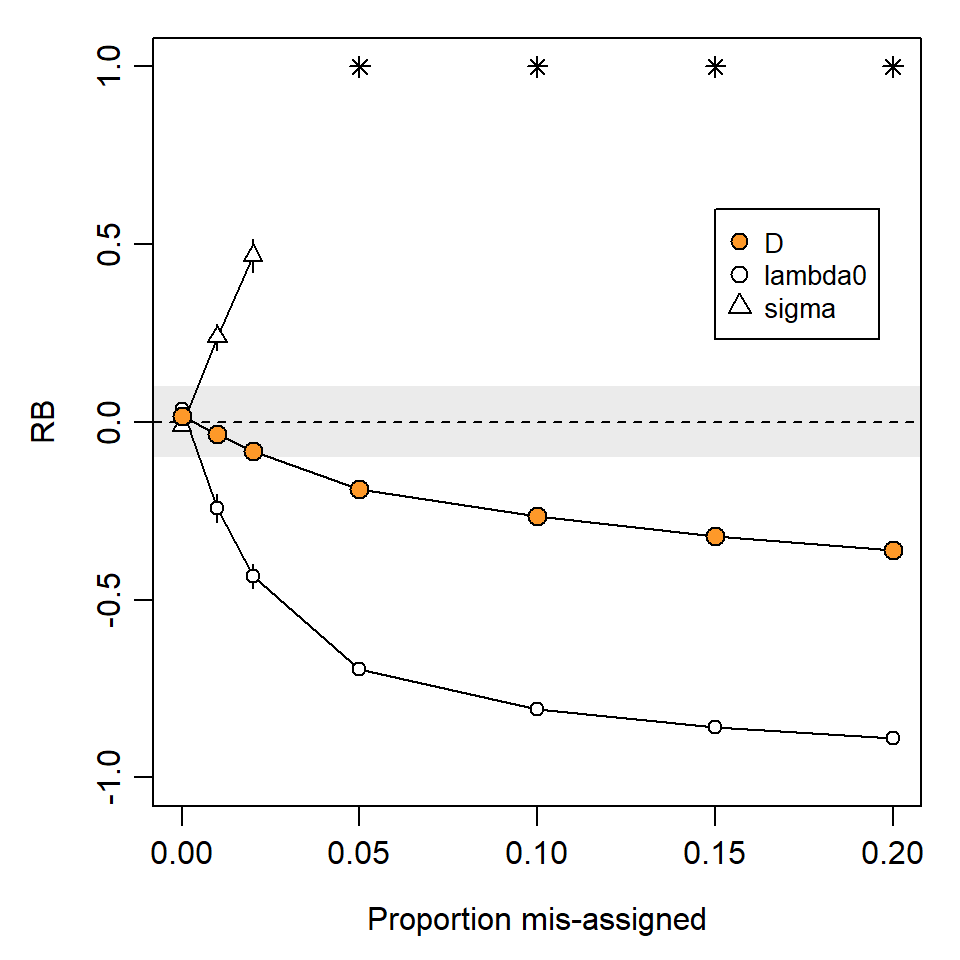

Figure: Relative bias of parameter estimates from null model given misidentification. Shaded band: |RB| < 10%.

### MID2 Ghost individuals

MIDsims2 completed with 200 replicates in 18.8 minutes.

```r
cbind(scenarios, getcounts(MIDsims2)[,-5])
```

```
##   pGhost     n     r  nmov   dpa  rpsv
## 1   0.00 111.6 88.60 51.21 1.459 19.15
## 2   0.01 110.0 84.01 48.91 1.444 19.35
## 3   0.02 113.9 83.50 49.09 1.431 19.36
## 4   0.05 118.0 80.12 46.91 1.398 19.31
## 5   0.10 124.0 73.00 42.87 1.346 19.21
## 6   0.15 129.7 64.42 37.85 1.292 19.16
## 7   0.20 136.1 59.19 34.99 1.257 19.18
```

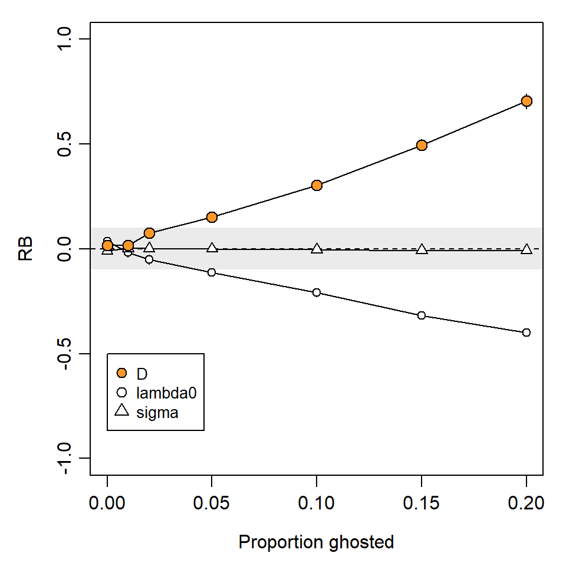

Figure: Relative bias of parameter estimates from null model vs frequency of ghost identities. Shaded band: |RB| < 10%

### MID3 Identical genotypes

MIDsims3 completed with 200 replicates in 25.3 minutes.

```
##          PI      n      r  nmov   dpa  rpsv
## 1 0.000e+00 111.61  88.60 51.21 1.459 19.15
## 2 1.000e-05 109.71  85.83 50.06 1.456 19.42
## 3 3.162e-05 109.25  85.58 49.95 1.457 19.80
## 4 1.000e-04 108.91  85.25 49.38 1.453 21.22
## 5 3.162e-04 109.58  89.17 52.44 1.479 24.75
## 6 1.000e-03 104.42  91.79 55.45 1.531 34.54
## 7 3.162e-03  91.86 108.23 70.10 1.763 52.50
## 8 1.000e-02  50.96 146.25 94.52 2.901 76.70
```

```
## Density
```

```
##          PI scenario true.D nvalid    EST  seEST      RB   seRB    RSE  RMSE  rRMSE    COV
## 1 0.000e+00        1   12.5    200 12.707 0.1025  0.0166 0.0082 0.1081 1.461 0.1168 0.9300
## 2 1.000e-05        2   12.5    200 12.517 0.0863  0.0014 0.0069 0.1093 1.218 0.0975 0.9700
## 3 3.162e-05        3   12.5    200 12.405 0.0930 -0.0076 0.0074 0.1091 1.315 0.1052 0.9400
## 4 1.000e-04        4   12.5    200 12.214 0.0991 -0.0229 0.0079 0.1094 1.427 0.1141 0.9500
## 5 3.162e-04        5   12.5    200 11.711 0.1037 -0.0632 0.0083 0.1074 1.662 0.1330 0.8550
## 6 1.000e-03        6   12.5    199  9.873 0.0813 -0.2102 0.0065 0.1111 2.865 0.2292 0.4573
## 7 3.162e-03        7   12.5    200  6.872 0.0579 -0.4502 0.0046 0.1135 5.686 0.4549 0.0000
## 8 1.000e-02        8   12.5    199  2.855 0.0371 -0.7716 0.0030 0.1426 9.659 0.7728 0.0000
```

```
## lambda0
```

```
##          PI scenario true.lambda0 nvalid    EST  seEST      RB   seRB    RSE   RMSE  rRMSE    COV
## 1 0.000e+00        1          0.1    200 0.1037 0.0010  0.0366 0.0101 0.1469 0.0147 0.1466 0.9650
## 2 1.000e-05        2          0.1    199 0.1000 0.0010  0.0004 0.0104 0.1490 0.0146 0.1458 0.9347
## 3 3.162e-05        3          0.1    194 0.0987 0.0012 -0.0130 0.0124 0.1480 0.0173 0.1727 0.8918
## 4 1.000e-04        4          0.1    189 0.0903 0.0016 -0.0966 0.0161 0.1463 0.0241 0.2411 0.7778
## 5 3.162e-04        5          0.1    171 0.0727 0.0019 -0.2734 0.0185 0.1460 0.0365 0.3649 0.4503
## 6 1.000e-03        6          0.1    185 0.0399 0.0013 -0.6008 0.0128 0.1506 0.0625 0.6255 0.0811
## 7 3.162e-03        7          0.1    200 0.0218 0.0004 -0.7815 0.0041 0.1353 0.0784 0.7836 0.0000
## 8 1.000e-02        8          0.1    199 0.0302 0.0008 -0.6978 0.0076 0.1249 0.0706 0.7060 0.0000
```

```
## sigma
```

```
##          PI scenario true.sigma nvalid   EST  seEST      RB   seRB    RSE   RMSE  rRMSE    COV
## 1 0.000e+00        1         20    200 19.81 0.0737 -0.0093 0.0037 0.0565  1.056 0.0528 0.9550
## 2 1.000e-05        2         20    198 20.07 0.0856  0.0033 0.0043 0.0577  1.203 0.0602 0.9545
## 3 3.162e-05        3         20    196 20.41 0.1300  0.0205 0.0065 0.0570  1.861 0.0931 0.8878
## 4 1.000e-04        4         20    190 21.85 0.2845  0.0923 0.0142 0.0570  4.325 0.2163 0.6947
## 5 3.162e-04        5         20    181 25.82 0.4191  0.2910 0.0210 0.0560  8.093 0.4047 0.3481
## 6 1.000e-03        6         20    190 38.13 0.6064  0.9067 0.0303 0.0625 19.959 0.9979 0.0368
## 7 3.162e-03        7         20    200 62.27 0.7657  2.1134 0.0383 0.0643 43.627 2.1813 0.0000
## 8 1.000e-02        8         20    199 96.54 0.5343  3.8271 0.0267 0.0553 76.911 3.8455 0.0000
```

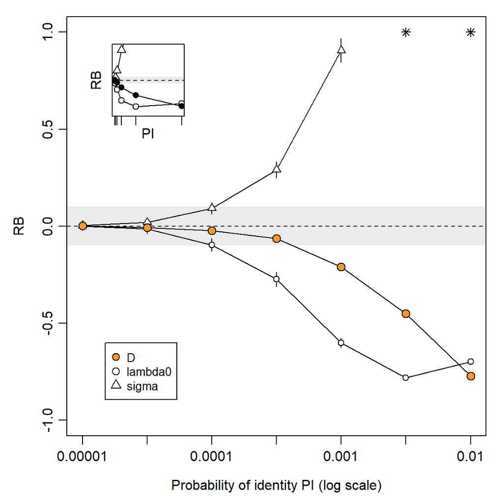

Figure: Relative bias of parameter estimates from null model when some individuals cannot be distinguished. Shaded band: |RB| < 10%. Inset shows same plot with arithmetic x-axis.

### MID4 Identical genotypes, varying density

MIDsims4 completed with 200 replicates in 129.5 minutes.

```
##           PI      D      n      r   nmov   dpa  rpsv
## 1  0.000e+00  3.125  27.70  21.50  12.54 1.450 19.04
## 2  1.000e-05  3.125  27.71  22.03  13.00 1.468 19.30
## 3  3.162e-05  3.125  27.87  21.90  12.95 1.464 19.64
## 4  1.000e-04  3.125  27.70  21.91  12.88 1.469 19.71
## 5  3.162e-04  3.125  27.54  21.81  12.97 1.471 21.43
## 6  1.000e-03  3.125  26.86  22.25  13.00 1.484 22.80
## 7  3.162e-03  3.125  27.25  23.66  14.41 1.527 31.47
## 8  1.000e-02  3.125  23.51  24.59  15.65 1.674 45.21
## 9  0.000e+00  6.250  55.41  43.10  24.95 1.451 19.27
## 10 1.000e-05  6.250  55.62  43.84  25.66 1.462 19.44
## 11 3.162e-05  6.250  55.52  43.06  25.06 1.451 19.41
## 12 1.000e-04  6.250  55.03  43.12  25.19 1.458 19.98
## 13 3.162e-04  6.250  55.46  45.62  26.68 1.480 22.07
## 14 1.000e-03  6.250  53.02  43.53  26.02 1.490 27.56
```

[output cut: 26 more lines]

```
##  Variable Definition
##  n        Number of individuals
##  r        Number of recaptures
##  nmov     Number of movements
##  dpa      Detectors per individual
##  rpsv     Approximate sigma-hat
```

```
## Density
```

```
##           PI      D scenario true.D nvalid    EST  seEST      RB   seRB    RSE    RMSE  rRMSE    COV
## 1  0.000e+00  3.125        1  3.125    200  3.257 0.0526  0.0421 0.0168 0.2272  0.7532 0.2410 0.9500
## 2  1.000e-05  3.125        2  3.125    200  3.231 0.0524  0.0340 0.0168 0.2254  0.7473 0.2391 0.9550
## 3  3.162e-05  3.125        3  3.125    200  3.252 0.0532  0.0406 0.0170 0.2257  0.7606 0.2434 0.9600
## 4  1.000e-04  3.125        4  3.125    200  3.187 0.0544  0.0198 0.0174 0.2248  0.7704 0.2465 0.9300
## 5  3.162e-04  3.125        5  3.125    200  3.158 0.0491  0.0106 0.0157 0.2267  0.6937 0.2220 0.9550
## 6  1.000e-03  3.125        6  3.125    200  2.943 0.0441 -0.0581 0.0141 0.2269  0.6484 0.2075 0.9700
## 7  3.162e-03  3.125        7  3.125    200  2.763 0.0499 -0.1159 0.0160 0.2250  0.7922 0.2535 0.8650
## 8  1.000e-02  3.125        8  3.125    200  2.004 0.0357 -0.3587 0.0114 0.2355  1.2288 0.3932 0.4400
## 9  0.000e+00  6.250        9  6.250    200  6.388 0.0718  0.0221 0.0115 0.1559  1.0229 0.1637 0.9350
## 10 1.000e-05  6.250       10  6.250    200  6.382 0.0726  0.0212 0.0116 0.1554  1.0329 0.1653 0.9300
## 11 3.162e-05  6.250       11  6.250    200  6.406 0.0731  0.0250 0.0117 0.1561  1.0437 0.1670 0.9500
## 12 1.000e-04  6.250       12  6.250    200  6.291 0.0719  0.0066 0.0115 0.1566  1.0145 0.1623 0.9400
## 13 3.162e-04  6.250       13  6.250    200  6.073 0.0677 -0.0283 0.0108 0.1545  0.9717 0.1555 0.9450
## 14 1.000e-03  6.250       14  6.250    200  5.541 0.0676 -0.1135 0.0108 0.1593  1.1884 0.1901 0.8650
```

[output cut: 26 more lines]

```
## lambda0
```

```
##           PI      D scenario true.lambda0 nvalid    EST  seEST      RB   seRB    RSE   RMSE  rRMSE    COV
## 1  0.000e+00  3.125        1          0.1    200 0.1041 0.0021  0.0413 0.0210 0.3140 0.0299 0.2994 0.9600
## 2  1.000e-05  3.125        2          0.1    200 0.1035 0.0020  0.0350 0.0203 0.3092 0.0289 0.2886 0.9600
## 3  3.162e-05  3.125        3          0.1    200 0.1011 0.0022  0.0112 0.0223 0.3106 0.0315 0.3148 0.9450
## 4  1.000e-04  3.125        4          0.1    200 0.1032 0.0023  0.0316 0.0232 0.3077 0.0329 0.3295 0.9200
## 5  3.162e-04  3.125        5          0.1    199 0.0938 0.0027 -0.0621 0.0270 0.3113 0.0385 0.3846 0.8442
## 6  1.000e-03  3.125        6          0.1    200 0.0899 0.0027 -0.1009 0.0268 0.3074 0.0391 0.3913 0.7700
## 7  3.162e-03  3.125        7          0.1    198 0.0607 0.0028 -0.3930 0.0285 0.3000 0.0560 0.5604 0.4545
## 8  1.000e-02  3.125        8          0.1    200 0.0338 0.0018 -0.6615 0.0185 0.2973 0.0711 0.7111 0.1450
## 9  0.000e+00  6.250        9          0.1    200 0.1017 0.0015  0.0166 0.0153 0.2133 0.0216 0.2164 0.9550
## 10 1.000e-05  6.250       10          0.1    200 0.1011 0.0016  0.0114 0.0157 0.2122 0.0221 0.2212 0.9300
## 11 3.162e-05  6.250       11          0.1    198 0.1009 0.0016  0.0087 0.0156 0.2150 0.0219 0.2191 0.9293
## 12 1.000e-04  6.250       12          0.1    200 0.0971 0.0017 -0.0294 0.0167 0.2119 0.0237 0.2372 0.9050
## 13 3.162e-04  6.250       13          0.1    190 0.0896 0.0021 -0.1036 0.0211 0.2097 0.0308 0.3076 0.7632
## 14 1.000e-03  6.250       14          0.1    196 0.0654 0.0023 -0.3461 0.0235 0.2149 0.0477 0.4765 0.4490
```

[output cut: 26 more lines]

```
## sigma
```

```
##           PI      D scenario true.sigma nvalid   EST  seEST      RB   seRB    RSE    RMSE  rRMSE    COV
## 1  0.000e+00  3.125        1         20    200 19.79 0.1546 -0.0105 0.0077 0.1190  2.1912 0.1096 0.9700
## 2  1.000e-05  3.125        2         20    200 20.00 0.1644  0.0002 0.0082 0.1171  2.3188 0.1159 0.9600
## 3  3.162e-05  3.125        3         20    200 20.40 0.2224  0.0202 0.0111 0.1178  3.1638 0.1582 0.9250
## 4  1.000e-04  3.125        4         20    200 20.55 0.2612  0.0276 0.0131 0.1174  3.7253 0.1863 0.9200
## 5  3.162e-04  3.125        5         20    199 22.42 0.5188  0.1211 0.0259 0.1196  7.6921 0.3846 0.8392
## 6  1.000e-03  3.125        6         20    200 24.07 0.5595  0.2034 0.0280 0.1190  8.8797 0.4440 0.7050
## 7  3.162e-03  3.125        7         20    199 34.80 1.1706  0.7399 0.0585 0.1225 22.1422 1.1071 0.3819
## 8  1.000e-02  3.125        8         20    200 52.96 1.4373  1.6481 0.0719 0.1324 38.6985 1.9349 0.1050
## 9  0.000e+00  6.250        9         20    200 20.00 0.1248 -0.0001 0.0062 0.0817  1.7604 0.0880 0.9250
## 10 1.000e-05  6.250       10         20    200 20.14 0.1262  0.0069 0.0063 0.0814  1.7855 0.0893 0.9250
## 11 3.162e-05  6.250       11         20    199 20.09 0.1598  0.0044 0.0080 0.0823  2.2497 0.1125 0.9246
## 12 1.000e-04  6.250       12         20    199 20.67 0.1911  0.0336 0.0096 0.0818  2.7713 0.1386 0.8744
## 13 3.162e-04  6.250       13         20    197 23.04 0.3826  0.1521 0.0191 0.0795  6.1601 0.3080 0.6802
## 14 1.000e-03  6.250       14         20    199 29.47 0.7038  0.4735 0.0352 0.0851 13.7034 0.6852 0.3367
```

[output cut: 26 more lines]

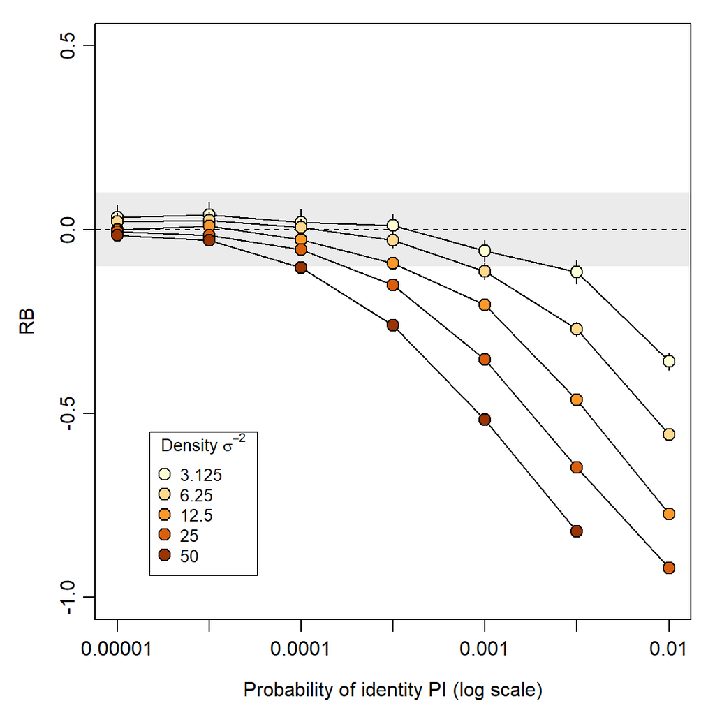

Figure: Relative bias of parameter estimates from null model when some individuals cannot be distinguished. Shaded band: |RB| < 10%.

From the curves in the previous figure we can interpolate the threshold PI at which relative bias of the density estimate from a null model exceeds a given threshold e.g. 5%. We plot this as a function of the expected number of individuals detected.

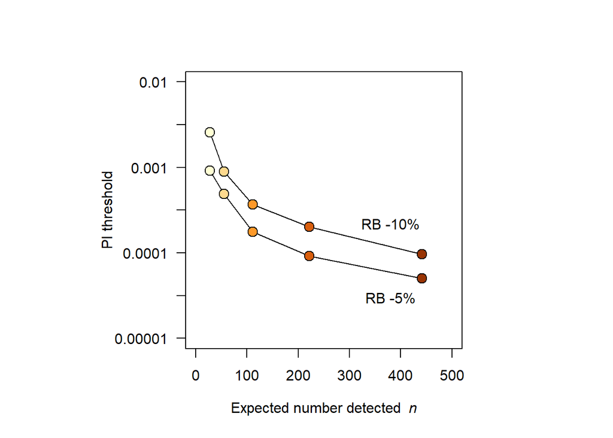

### MID5 identical genotypes, varying detection probability

MIDsims5 completed with 200 replicates in 78.1 minutes.

```
##           PI lambda0      n      r   nmov   dpa  rpsv
## 1  0.000e+00    0.05  72.53  26.38  16.46 1.226 19.29
## 2  1.000e-05    0.05  73.17  27.04  16.87 1.230 19.57
## 3  3.162e-05    0.05  72.61  26.57  16.36 1.226 19.57
## 4  1.000e-04    0.05  72.93  27.17  16.82 1.230 21.18
## 5  3.162e-04    0.05  71.47  27.88  17.58 1.246 25.47
## 6  1.000e-03    0.05  69.88  28.85  18.89 1.270 33.95
## 7  3.162e-03    0.05  63.99  34.65  24.52 1.383 50.88
## 8  1.000e-02    0.05  45.77  52.95  41.10 1.910 74.58
## 9  0.000e+00    0.10 109.74  85.00  49.77 1.454 19.30
## 10 1.000e-05    0.10 110.27  85.81  50.12 1.455 19.60
## 11 3.162e-05    0.10 109.81  86.26  50.01 1.455 19.84
## 12 1.000e-04    0.10 109.42  86.33  50.76 1.464 21.38
## 13 3.162e-04    0.10 108.63  88.14  52.31 1.482 25.51
## 14 1.000e-03    0.10 104.02  91.78  55.67 1.535 34.39
## 15 3.162e-03    0.10  91.01 105.53  68.20 1.750 52.12
## 16 1.000e-02    0.10  50.69 144.76  92.51 2.871 77.66
## 17 0.000e+00    0.20 142.01 242.38 124.14 1.875 19.30
## 18 1.000e-05    0.20 142.76 241.16 123.47 1.864 19.47
## 19 3.162e-05    0.20 141.55 244.74 124.84 1.882 19.77
## 20 1.000e-04    0.20 141.44 243.27 124.78 1.883 20.98
## 21 3.162e-04    0.20 138.94 244.06 126.82 1.913 24.95
## 22 1.000e-03    0.20 131.34 251.78 133.28 2.014 33.68
## 23 3.162e-03    0.20 109.61 274.38 153.50 2.403 52.12
## 24 1.000e-02    0.20  46.37 334.38 137.50 4.007 79.83
```

```
##  Variable Definition
##  n        Number of individuals
##  r        Number of recaptures
##  nmov     Number of movements
##  dpa      Detectors per individual
##  rpsv     Approximate sigma-hat
```

```
## Density
```

```
##           PI lambda0 scenario true.D nvalid    EST  seEST      RB   seRB    RSE  RMSE  rRMSE    COV
## 1  0.000e+00    0.05        1   12.5    200 12.886 0.1644  0.0309 0.0132 0.1833 2.351 0.1881 0.9700
## 2  1.000e-05    0.05        2   12.5    200 12.818 0.1602  0.0254 0.0128 0.1812 2.282 0.1826 0.9700
## 3  3.162e-05    0.05        3   12.5    200 12.867 0.1730  0.0293 0.0138 0.1825 2.468 0.1975 0.9450
## 4  1.000e-04    0.05        4   12.5    200 12.611 0.1595  0.0088 0.0128 0.1815 2.253 0.1802 0.9600
## 5  3.162e-04    0.05        5   12.5    200 11.570 0.1593 -0.0744 0.0127 0.1803 2.432 0.1945 0.8950
## 6  1.000e-03    0.05        6   12.5    200 10.242 0.1477 -0.1806 0.0118 0.1798 3.072 0.2457 0.7000
## 7  3.162e-03    0.05        7   12.5    200  7.137 0.1055 -0.4290 0.0084 0.1703 5.566 0.4452 0.1050
## 8  1.000e-02    0.05        8   12.5    200  3.209 0.0410 -0.7433 0.0033 0.1619 9.309 0.7447 0.0000
## 9  0.000e+00    0.10        9   12.5    200 12.571 0.0930  0.0056 0.0074 0.1096 1.314 0.1051 0.9650
## 10 1.000e-05    0.10       10   12.5    199 12.632 0.0959  0.0106 0.0077 0.1092 1.356 0.1085 0.9698
## 11 3.162e-05    0.10       11   12.5    199 12.489 0.0943 -0.0009 0.0075 0.1088 1.328 0.1062 0.9548
## 12 1.000e-04    0.10       12   12.5    200 12.223 0.1044 -0.0222 0.0084 0.1082 1.499 0.1199 0.9000
## 13 3.162e-04    0.10       13   12.5    197 11.559 0.1010 -0.0753 0.0081 0.1095 1.699 0.1359 0.8376
## 14 1.000e-03    0.10       14   12.5    200  9.876 0.0830 -0.2099 0.0066 0.1110 2.873 0.2299 0.4100
## 15 3.162e-03    0.10       15   12.5    200  6.858 0.0607 -0.4514 0.0049 0.1143 5.707 0.4566 0.0000
## 16 1.000e-02    0.10       16   12.5    200  2.835 0.0377 -0.7732 0.0030 0.1431 9.679 0.7743 0.0000
## 17 0.000e+00    0.20       17   12.5    200 12.530 0.0742  0.0024 0.0059 0.0861 1.047 0.0838 0.9500
## 18 1.000e-05    0.20       18   12.5    200 12.599 0.0774  0.0079 0.0062 0.0860 1.097 0.0877 0.9450
## 19 3.162e-05    0.20       19   12.5    200 12.388 0.0784 -0.0089 0.0063 0.0863 1.112 0.0889 0.9450
## 20 1.000e-04    0.20       20   12.5    199 12.220 0.0825 -0.0224 0.0066 0.0861 1.195 0.0956 0.9246
## 21 3.162e-04    0.20       21   12.5    200 11.375 0.0869 -0.0900 0.0070 0.0869 1.664 0.1331 0.7600
## 22 1.000e-03    0.20       22   12.5    200  9.645 0.0645 -0.2284 0.0052 0.0894 2.996 0.2397 0.1550
## 23 3.162e-03    0.20       23   12.5    200  6.670 0.0445 -0.4664 0.0036 0.0973 5.864 0.4691 0.0000
## 24 1.000e-02    0.20       24   12.5    130  2.596 0.0346 -0.7923 0.0028 0.1449 9.912 0.7929 0.0000
```

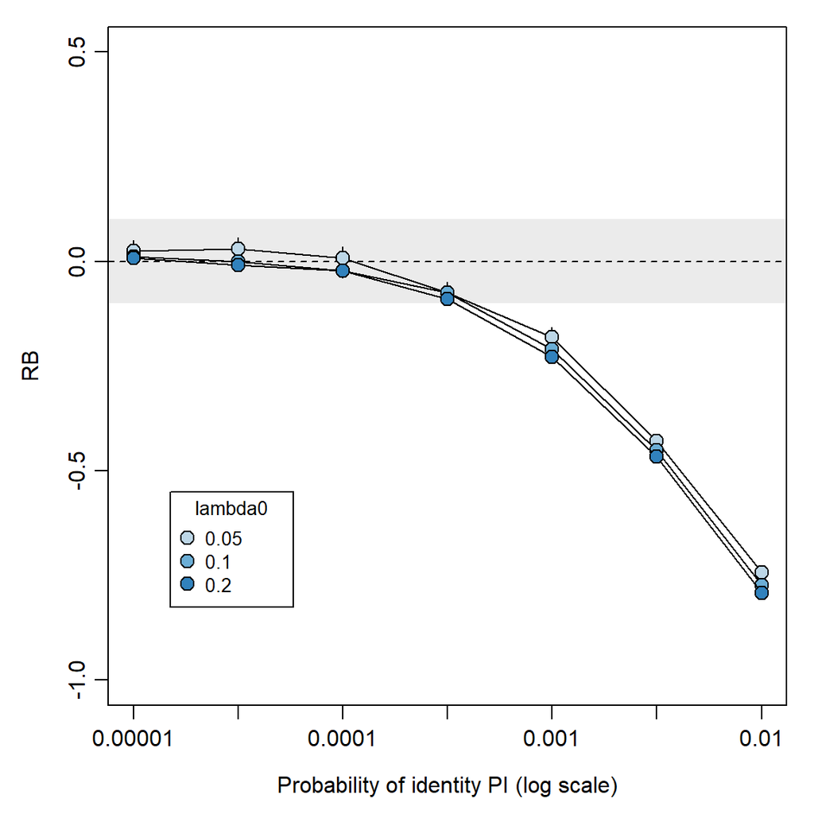

Figure: Relative bias of parameter estimates from null model when some individuals cannot be distinguished. Shaded band: |RB| < 10%.

### MID6 Tag loss

MIDsims6 completed with 200 replicates in 32.6 minutes.

```
##     noccasions pTagloss     n      r   nmov   dpa  rpsv
## 1            5    0.000 109.6  81.81  50.01 1.456 19.66
## 1.1         10    0.000 141.6 239.75 122.42 1.865 19.29
## 2            5    0.002 110.4  78.94  48.72 1.441 19.66
## 2.1         10    0.002 141.5 238.26 122.56 1.866 19.37
## 3            5    0.005 110.6  80.60  49.58 1.448 19.69
## 3.1         10    0.005 146.1 241.31 124.24 1.850 19.36
## 4            5    0.010 111.4  81.12  50.66 1.455 19.88
## 4.1         10    0.010 146.7 233.85 120.55 1.821 19.32
## 5            5    0.020 112.3  78.50  48.95 1.436 19.77
## 5.1         10    0.020 152.0 230.18 119.50 1.786 19.35
## 6            5    0.050 114.8  75.47  46.81 1.408 19.80
## 6.1         10    0.050 166.1 216.07 115.13 1.694 19.45
## 7            5    0.100 120.6  71.08  44.70 1.371 19.90
## 7.1         10    0.100 187.0 190.62 106.08 1.567 19.57
## 8            5    0.150 126.0  66.44  43.00 1.341 20.05
## 8.1         10    0.150 207.3 173.76 100.53 1.486 19.73
## 9            5    0.200 130.7  60.67  39.62 1.303 19.90
## 9.1         10    0.200 224.3 158.11  93.95 1.419 19.70
```

```
##  Variable Definition
##  n        Number of individuals
##  r        Number of recaptures
##  nmov     Number of movements
##  dpa      Detectors per individual
##  rpsv     Approximate sigma-hat
```

```
## Density
```

```
##     noccasions pTagloss true.D nvalid   EST  seEST     RB   seRB    RSE    RMSE  rRMSE   COV
## 1            5    0.000   12.5    200 12.51 0.1013 0.0010 0.0081 0.1098  1.4289 0.1143 0.920
## 1.1         10    0.000   12.5    200 12.51 0.0719 0.0012 0.0057 0.0863  1.0137 0.0811 0.970
## 2            5    0.002   12.5    200 12.82 0.0866 0.0254 0.0069 0.1106  1.2616 0.1009 0.965
## 2.1         10    0.002   12.5    200 12.51 0.0694 0.0005 0.0055 0.0863  0.9784 0.0783 0.965
## 3            5    0.005   12.5    200 12.73 0.0994 0.0184 0.0080 0.1099  1.4212 0.1137 0.935
## 3.1         10    0.005   12.5    200 12.99 0.0835 0.0392 0.0067 0.0851  1.2754 0.1020 0.900
## 4            5    0.010   12.5    200 12.82 0.1064 0.0257 0.0085 0.1097  1.5343 0.1227 0.930
## 4.1         10    0.010   12.5    200 13.15 0.0845 0.0521 0.0068 0.0851  1.3587 0.1087 0.870
## 5            5    0.020   12.5    200 13.14 0.1108 0.0511 0.0089 0.1104  1.6884 0.1351 0.890
## 5.1         10    0.020   12.5    200 13.79 0.0934 0.1034 0.0075 0.0839  1.8458 0.1477 0.750
## 6            5    0.050   12.5    200 13.91 0.1166 0.1130 0.0093 0.1114  2.1676 0.1734 0.835
## 6.1         10    0.050   12.5    200 15.73 0.1051 0.2584 0.0084 0.0813  3.5539 0.2843 0.240
## 7            5    0.100   12.5    200 15.41 0.1357 0.2329 0.0109 0.1125  3.4842 0.2787 0.550
## 7.1         10    0.100   12.5    200 19.09 0.1225 0.5273 0.0098 0.0791  6.8145 0.5452 0.005
## 8            5    0.150   12.5    200 17.03 0.1416 0.3625 0.0113 0.1149  4.9519 0.3962 0.230
## 8.1         10    0.150   12.5    200 22.83 0.1767 0.8261 0.0141 0.0781 10.6233 0.8499 0.000
## 9            5    0.200   12.5    200 19.06 0.1891 0.5246 0.0151 0.1189  7.0800 0.5664 0.095
## 9.1         10    0.200   12.5    200 26.73 0.1928 1.1383 0.0154 0.0785 14.4864 1.1589 0.000
```

```
## lambda0
```

```
##     noccasions pTagloss true.lambda0 nvalid    EST  seEST      RB   seRB    RSE   RMSE  rRMSE   COV
## 1            5    0.000          0.2    200 0.2047 0.0022  0.0234 0.0109 0.1554 0.0312 0.1559 0.940
## 1.1         10    0.000          0.2    200 0.2009 0.0012  0.0047 0.0060 0.0889 0.0168 0.0842 0.965
## 2            5    0.002          0.2    200 0.1974 0.0022 -0.0129 0.0110 0.1582 0.0312 0.1562 0.950
## 2.1         10    0.002          0.2    200 0.1983 0.0012 -0.0085 0.0061 0.0892 0.0173 0.0866 0.965
## 3            5    0.005          0.2    200 0.1997 0.0021 -0.0017 0.0105 0.1565 0.0295 0.1477 0.970
## 3.1         10    0.005          0.2    200 0.1946 0.0012 -0.0269 0.0061 0.0887 0.0181 0.0905 0.930
## 4            5    0.010          0.2    200 0.1960 0.0022 -0.0201 0.0108 0.1561 0.0306 0.1532 0.950
## 4.1         10    0.010          0.2    200 0.1901 0.0013 -0.0495 0.0063 0.0900 0.0202 0.1012 0.885
## 5            5    0.020          0.2    200 0.1918 0.0022 -0.0412 0.0109 0.1585 0.0319 0.1594 0.915
## 5.1         10    0.020          0.2    200 0.1809 0.0012 -0.0957 0.0058 0.0907 0.0251 0.1255 0.810
## 6            5    0.050          0.2    200 0.1799 0.0021 -0.1003 0.0104 0.1623 0.0357 0.1783 0.925
## 6.1         10    0.050          0.2    200 0.1562 0.0011 -0.2188 0.0054 0.0936 0.0463 0.2316 0.240
## 7            5    0.100          0.2    200 0.1611 0.0018 -0.1946 0.0091 0.1672 0.0467 0.2334 0.710
## 7.1         10    0.100          0.2    200 0.1245 0.0010 -0.3773 0.0049 0.0997 0.0767 0.3835 0.000
## 8            5    0.150          0.2    200 0.1430 0.0016 -0.2851 0.0082 0.1736 0.0615 0.3077 0.490
## 8.1         10    0.150          0.2    200 0.1031 0.0009 -0.4843 0.0043 0.1044 0.0976 0.4881 0.000
## 9            5    0.200          0.2    200 0.1294 0.0017 -0.3531 0.0084 0.1824 0.0745 0.3723 0.345
## 9.1         10    0.200          0.2    200 0.0882 0.0007 -0.5590 0.0036 0.1097 0.1123 0.5613 0.000
```

```
## sigma
```

```
##     noccasions pTagloss true.sigma nvalid   EST  seEST      RB   seRB    RSE   RMSE  rRMSE   COV
## 1            5    0.000         20    200 19.90 0.0820 -0.0048 0.0041 0.0584 1.1612 0.0581 0.955
## 1.1         10    0.000         20    200 19.94 0.0469 -0.0028 0.0023 0.0343 0.6643 0.0332 0.955
## 2            5    0.002         20    200 19.92 0.0842 -0.0039 0.0042 0.0595 1.1899 0.0595 0.925
## 2.1         10    0.002         20    200 20.04 0.0511  0.0019 0.0026 0.0345 0.7218 0.0361 0.945
## 3            5    0.005         20    200 19.97 0.0774 -0.0017 0.0039 0.0590 1.0920 0.0546 0.970
## 3.1         10    0.005         20    200 20.02 0.0535  0.0010 0.0027 0.0342 0.7551 0.0378 0.930
## 4            5    0.010         20    200 20.16 0.0810  0.0079 0.0040 0.0588 1.1533 0.0577 0.970
## 4.1         10    0.010         20    200 19.98 0.0518 -0.0009 0.0026 0.0348 0.7306 0.0365 0.950
## 5            5    0.020         20    200 20.07 0.0863  0.0033 0.0043 0.0597 1.2196 0.0610 0.945
## 5.1         10    0.020         20    200 20.02 0.0487  0.0008 0.0024 0.0351 0.6878 0.0344 0.950
## 6            5    0.050         20    200 20.05 0.0822  0.0025 0.0041 0.0609 1.1613 0.0581 0.970
## 6.1         10    0.050         20    200 20.10 0.0516  0.0049 0.0026 0.0362 0.7338 0.0367 0.970
## 7            5    0.100         20    200 20.16 0.0864  0.0082 0.0043 0.0627 1.2304 0.0615 0.945
## 7.1         10    0.100         20    200 20.28 0.0583  0.0142 0.0029 0.0387 0.8694 0.0435 0.940
## 8            5    0.150         20    200 20.37 0.0947  0.0185 0.0047 0.0652 1.3856 0.0693 0.950
## 8.1         10    0.150         20    200 20.45 0.0587  0.0225 0.0029 0.0405 0.9420 0.0471 0.925
## 9            5    0.200         20    200 20.22 0.0907  0.0110 0.0045 0.0684 1.2976 0.0649 0.975
## 9.1         10    0.200         20    200 20.41 0.0562  0.0204 0.0028 0.0424 0.8916 0.0446 0.955
```

```r
# when does RB exceed 10%?
OK <- scenarios$noccasions == 5
approx(estD[OK,]$RB, scenarios$pTagloss[OK], xout=0.1)$y
```

```
## [1] 0.04371
```

```r
OK <- scenarios$noccasions == 10
approx(estD[OK,]$RB, scenarios$pTagloss[OK], xout=0.1)$y
```

```
## [1] 0.01934
```

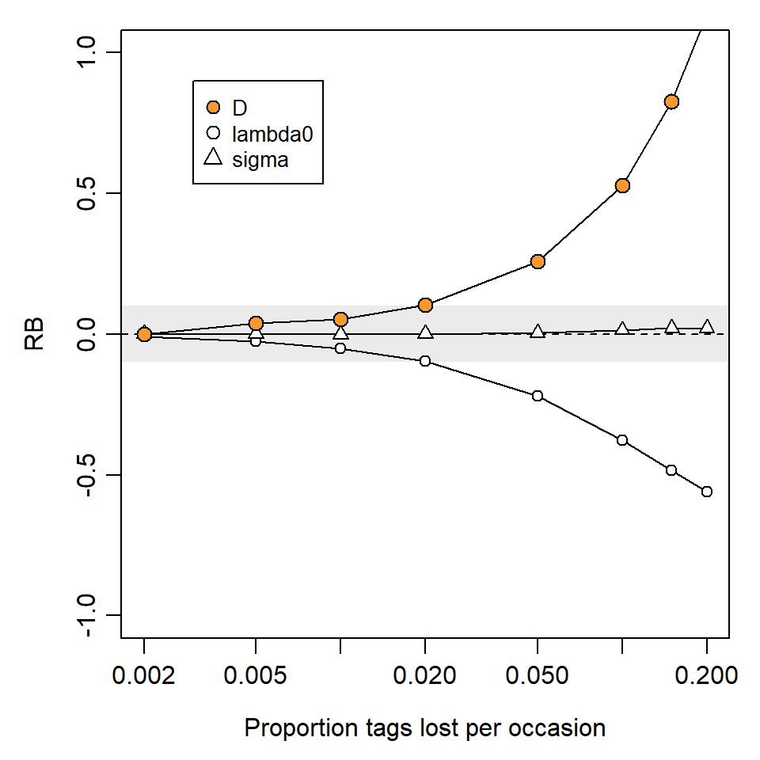

Figure: Relative bias of parameter estimates from null model given tag loss. Shaded band: |RB| < 10%.

## Interpretation

### MID1

Random mis-identification of individuals in more than about 2% of detection events caused significant negative bias in estimates of density from the null model ($RB(\hat D) < -10\%$). The simulation model was only an approximation to study conditions as it *excluded* the possibility that mis-identification placed an individual outside the set of otherwise known individuals (i.e., as a new never-to-be-seen-again ghost individual).

### MID2

Ghost individuals caused positive relative bias in density estimates on the order of 3 times their frequency of occurrence expressed as a proportion of all detections ($RB(\hat D) > +10\%$ when $\mbox{pGhost}>0.032$). The simulated high frequencies (>5%) seem rather improbable. Estimates of $\sigma$ remained unbiased (with potentially a slight reduction in precision owing to the reduced number of recaptures).

### MID3

Density estimates were sensitive to the presence of identical genotypes. Any $\mbox{PI} > 0.0004$ resulted in significant negative bias ($RB(\hat D) < -10\%$). Bias is not directly attributable to a reduction in the number of distinct individuals, as this varied little at this threshold. For 110 observed individuals there are 5995 pairwise possible identities, The threshold PI corresponds to an average of just 2.4 pairs

### MID4

Varying true density has a large effect on the relationship between PI and bias in $\hat D$. This effect is probably due to the increased number of individuals that are detected and therefore potentially confused. Parameters of detection ($\lambda_0, \sigma$) also affect the number detected.

### MID6

Tag loss caused positive relative bias in density estimates on the order of the per-occasion probability (pTagloss) times the number of occasions divided by 2. In the simulations with 10 occasions, $RB(\hat D) > +10\%$ when pTagloss $>$ 0.019; the threshold increased to 0.044 when the number pf occasions was reduced to 5. Estimates of $\sigma$ remained unbiased (with potentially a slight reduction in precision owing to the reduced number of recaptures).